# DS202: Lab 4

Muhammad Khairi Norizan

10/26/2021

## Part 1: Cleaning Data

1. The player names and opponent names should be factors.

```r
defClean$Name <- as.factor(defClean$Name)
offClean$Name <- as.factor(offClean$Name)
```

2. All offensive and defensive statistics should be numerical. The `Weight` column in biography should also be numeric. (Optional: Read `?across` and learn to mutate multiple columns simultaneously using the `across` function in `dplyr`)

```r
defClean <- defClean %>% mutate(across(Tackles_Solo:Pass_PB, as.numeric))

offClean <- offClean

offClean <- offClean %>%
  separate(Passing_CMPATT, c('Passing_CMP', 'Passing_ATT'), sep = "-")
offClean <- offClean %>% mutate(across(Receiving_REC:Passing_INT, as.numeric))
bioClean$Weight <- as.numeric(biography$Weight)
```

3. The `Height` column in `biography` should be numeric. (Hint: Use a unit that works well)

```r
bioClean <- bioClean %>%
            separate(Height, c('feet', 'inches'), "-", convert = TRUE) %>%
            mutate(height = (12*feet + inches)*2.54) %>% select(-c('feet', 'inches')) %>%
            rename('height(cm)'=height)
```

4. Add a column to both `defense` and `offense` indicating whether it is the first or the second game versus an opponent. We had a single game versus each opponent except for Oklahoma, which we played against twice. (Hint: You can use `group_by()`, `mutate()`, and `row_number()`)

```r
offClean <- offClean %>%
  group_by(Name) %>%
  mutate(FirstTime = !duplicated(Opponent_Opponent))

defClean <- defClean %>%
  group_by(Name) %>%
  mutate(FirstTime = !duplicated(Opponent_Opponent))
```

```r
print(str(offClean))
```

```
## grouped_df [156 × 14] (S3: grouped_df/tbl_df/tbl/data.frame)
##  $ Name             : Factor w/ 16 levels "Akers, Landen",..: 1 1 1 1 1 1 1 1 1 1 ...
##  $ Opponent_Opponent: chr [1:156] "Louisiana" "TCU" "Oklahoma" "Texas Tech" ...
##  $ Receiving_REC    : num [1:156] 0 2 1 4 0 6 1 0 1 1 ...
##  $ Receiving_YDS    : num [1:156] 0 60 35 34 0 76 11 0 10 2 ...
##  $ Receiving_TD     : num [1:156] 0 0 0 0 0 0 0 0 0 1 ...
##  $ Rushing_ATT      : num [1:156] NA NA NA NA NA NA NA NA NA NA ...
##  $ Rushing_YDS      : num [1:156] NA NA NA NA NA NA NA NA NA NA ...
##  $ Rushing_TD       : num [1:156] NA NA NA NA NA NA NA NA NA NA ...
##  $ Passing_CMP      : num [1:156] NA NA NA NA NA NA NA NA NA NA ...
##  $ Passing_ATT      : num [1:156] NA NA NA NA NA NA NA NA NA NA ...
##  $ Passing_YDS      : num [1:156] NA NA NA NA NA NA NA NA NA NA ...
##  $ Passing_TD       : num [1:156] NA NA NA NA NA NA NA NA NA NA ...
##  $ Passing_INT      : num [1:156] NA NA NA NA NA NA NA NA NA NA ...
##  $ FirstTime        : logi [1:156] TRUE TRUE TRUE TRUE TRUE TRUE ...
##  - attr(*, "groups")= tibble [16 × 2] (S3: tbl_df/tbl/data.frame)
##   ..$ Name : Factor w/ 16 levels "Akers, Landen",..: 1 2 3 4 5 6 7 8 9 10 ...
##   ..$ .rows: list<int> [1:16]
##   .. ..$ : int [1:12] 1 2 3 4 5 6 7 8 9 10 ...
##   .. ..$ : int [1:11] 107 108 109 110 111 112 113 114 115 116 ...
##   .. ..$ : int [1:5] 136 137 138 139 140
##   .. ..$ : int [1:10] 13 14 15 16 17 18 19 20 21 22
##   .. ..$ : int [1:12] 145 146 147 148 149 150 151 152 153 154 ...
##   .. ..$ : int [1:3] 93 94 95
##   .. ..$ : int [1:12] 81 82 83 84 85 86 87 88 89 90 ...
##   .. ..$ : int [1:12] 23 24 25 26 27 28 29 30 31 32 ...
##   .. ..$ : int [1:4] 141 142 143 144
##   .. ..$ : int [1:11] 96 97 98 99 100 101 102 103 104 105 ...
##   .. ..$ : int [1:6] 130 131 132 133 134 135
##   .. ..$ : int [1:12] 35 36 37 38 39 40 41 42 43 44 ...
##   .. ..$ : int [1:12] 47 48 49 50 51 52 53 54 55 56 ...
##   .. ..$ : int [1:11] 59 60 61 62 63 64 65 66 67 68 ...
##   .. ..$ : int [1:12] 118 119 120 121 122 123 124 125 126 127 ...
##   .. ..$ : int [1:11] 70 71 72 73 74 75 76 77 78 79 ...
##   .. ..@ ptype: int(0)
##   ..- attr(*, ".drop")= logi TRUE
## NULL
```

```r
print(str(defClean))
```

```
## grouped_df [372 × 12] (S3: grouped_df/tbl_df/tbl/data.frame)
##  $ Name             : Factor w/ 37 levels "Akers, Landen",..: 26 26 26 26 26 26 26 26 26 26 ...
##  $ Opponent_Opponent: chr [1:372] "Louisiana" "TCU" "Oklahoma" "Texas Tech" ...
##  $ Tackles_Solo     : num [1:372] 2 6 6 3 7 4 7 4 4 2 ...
##  $ Tackles_ASST     : num [1:372] 4 4 5 0 3 1 4 3 9 3 ...
##  $ Tackles_TFL      : num [1:372] 1 0 1.5 1 1 0 1.5 2.5 1.5 0 ...
##  $ Tackles_Sack     : num [1:372] 0 0 0.5 0 0 0 0 1 0 0 ...
##  $ Turnover_FF      : num [1:372] 0 0 0 0 0 0 0 0 0 0 ...
##  $ Turnover_FR      : num [1:372] 0 0 0 0 0 0 0 0 0 0 ...
##  $ Turnover_INT     : num [1:372] 0 1 0 0 1 0 1 1 0 0 ...
##  $ Pass_QBH         : num [1:372] 0 0 1 0 0 0 2 1 0 0 ...
##  $ Pass_PB          : num [1:372] 0 0 0 0 0 1 0 0 1 0 ...
##  $ FirstTime        : logi [1:372] TRUE TRUE TRUE TRUE TRUE TRUE ...
##  - attr(*, "groups")= tibble [37 × 2] (S3: tbl_df/tbl/data.frame)
##   ..$ Name : Factor w/ 37 levels "Akers, Landen",..: 1 2 3 4 5 6 7 8 9 10 ...
##   ..$ .rows: list<int> [1:37]
##   .. ..$ : int [1:12] 193 194 195 196 197 198 199 200 201 202 ...
##   .. ..$ : int [1:9] 61 62 63 64 65 66 67 68 69
##   .. ..$ : int [1:12] 49 50 51 52 53 54 55 56 57 58 ...
##   .. ..$ : int [1:12] 140 141 142 143 144 145 146 147 148 149 ...
##   .. ..$ : int [1:11] 129 130 131 132 133 134 135 136 137 138 ...
##   .. ..$ : int [1:10] 277 278 279 280 281 282 283 284 285 286
##   .. ..$ : int [1:6] 244 245 246 247 248 249
##   .. ..$ : int [1:12] 205 206 207 208 209 210 211 212 213 214 ...
##   .. ..$ : int [1:12] 287 288 289 290 291 292 293 294 295 296 ...
##   .. ..$ : int [1:11] 152 153 154 155 156 157 158 159 160 161 ...
##   .. ..$ : int [1:12] 13 14 15 16 17 18 19 20 21 22 ...
##   .. ..$ : int [1:12] 299 300 301 302 303 304 305 306 307 308 ...
##   .. ..$ : int [1:2] 311 312
##   .. ..$ : int [1:8] 185 186 187 188 189 190 191 192
##   .. ..$ : int [1:12] 70 71 72 73 74 75 76 77 78 79 ...
##   .. ..$ : int [1:10] 175 176 177 178 179 180 181 182 183 184
##   .. ..$ : int [1:4] 313 314 315 316
##   .. ..$ : int [1:7] 259 260 261 262 263 264 265
##   .. ..$ : int [1:12] 317 318 319 320 321 322 323 324 325 326 ...
##   .. ..$ : int [1:3] 329 330 331
##   .. ..$ : int [1:9] 250 251 252 253 254 255 256 257 258
##   .. ..$ : int [1:12] 117 118 119 120 121 122 123 124 125 126 ...
##   .. ..$ : int [1:6] 217 218 219 220 221 222
##   .. ..$ : int [1:12] 223 224 225 226 227 228 229 230 231 232 ...
##   .. ..$ : int [1:12] 332 333 334 335 336 337 338 339 340 341 ...
##   .. ..$ : int [1:12] 1 2 3 4 5 6 7 8 9 10 ...
##   .. ..$ : int [1:11] 266 267 268 269 270 271 272 273 274 275 ...
##   .. ..$ : int [1:11] 344 345 346 347 348 349 350 351 352 353 ...
##   .. ..$ : int [1:11] 355 356 357 358 359 360 361 362 363 364 ...
##   .. ..$ : int [1:7] 366 367 368 369 370 371 372
##   .. ..$ : int [1:9] 235 236 237 238 239 240 241 242 243
##   .. ..$ : int [1:12] 82 83 84 85 86 87 88 89 90 91 ...
##   .. ..$ : int [1:12] 25 26 27 28 29 30 31 32 33 34 ...
##   .. ..$ : int [1:12] 105 106 107 108 109 110 111 112 113 114 ...
##   .. ..$ : int [1:12] 163 164 165 166 167 168 169 170 171 172 ...
##   .. ..$ : int [1:11] 94 95 96 97 98 99 100 101 102 103 ...
##   .. ..$ : int [1:12] 37 38 39 40 41 42 43 44 45 46 ...
##   .. ..@ ptype: int(0)
##   ..- attr(*, ".drop")= logi TRUE
## NULL
```

```r
print(str(bioClean))
```

```
## 'data.frame':    116 obs. of  7 variables:
##  $ Name      : chr  "Akers, Landen" "Allen, Chase" "Anderson, Ezeriah" "Antoine Jr. , Michal" ...
##  $ Position  : chr  "Wide Receiver" "Tight End" "Wide Receiver" "Defensive Back" ...
##  $ Weight    : num  191 240 208 180 195 199 253 261 288 182 ...
##  $ Class     : chr  "Redshirt Senior" "Redshirt Senior" "Redshirt Freshman" "Freshman" ...
##  $ Hometown  : chr  "Cedar Rapids, Iowa" "Nixa, Mo." "Seffner, Fla." "Ft. Lauderdale, Fla." ...
##  $ Highschool: chr  "Washington" "Nixa" "Armwood" "Cardinal Gibbons" ...
##  $ height(cm): num  183 201 196 183 183 ...
## NULL
```

## Part 2: Tidying and exploring

1. Reformat the `offClean` data frame into a tidy format using pivot_longer. The type of statistic (Receiving_REC for the number of receiving, Receiving_YDS for receiving yards, etc) is added as a new key column named `stat`.

```r
offClean <- offClean %>% pivot_longer(Receiving_REC:Passing_INT, names_to = "stat", values_to = "Value")
print(offClean)
```

```
## # A tibble: 1,716 × 5
## # Groups:   Name [16]
##    Name          Opponent_Opponent FirstTime stat          Value
##    <fct>         <chr>             <lgl>     <chr>         <dbl>
##  1 Akers, Landen Louisiana         TRUE      Receiving_REC     0
##  2 Akers, Landen Louisiana         TRUE      Receiving_YDS     0
##  3 Akers, Landen Louisiana         TRUE      Receiving_TD      0
##  4 Akers, Landen Louisiana         TRUE      Rushing_ATT      NA
##  5 Akers, Landen Louisiana         TRUE      Rushing_YDS      NA
##  6 Akers, Landen Louisiana         TRUE      Rushing_TD       NA
##  7 Akers, Landen Louisiana         TRUE      Passing_CMP      NA
##  8 Akers, Landen Louisiana         TRUE      Passing_ATT      NA
##  9 Akers, Landen Louisiana         TRUE      Passing_YDS      NA
## 10 Akers, Landen Louisiana         TRUE      Passing_TD       NA
## # … with 1,706 more rows
```

2. Obtain the player-level offensive statistics. Namely, for each player and each type of statistics, obtain the sum of the statistics in all games

```r
playerOffenseStat <- offClean %>%
                      group_by(Name, stat) %>%
                      summarize(statSum = sum(Value, na.rm = TRUE))
print(playerOffenseStat)
```

```
## # A tibble: 176 × 3
## # Groups:   Name [16]
##    Name          stat          statSum
##    <fct>         <chr>           <dbl>
##  1 Akers, Landen Passing_ATT         0
##  2 Akers, Landen Passing_CMP         0
##  3 Akers, Landen Passing_INT         0
##  4 Akers, Landen Passing_TD          0
##  5 Akers, Landen Passing_YDS         0
##  6 Akers, Landen Receiving_REC      18
##  7 Akers, Landen Receiving_TD        1
##  8 Akers, Landen Receiving_YDS     269
##  9 Akers, Landen Rushing_ATT         0
## 10 Akers, Landen Rushing_TD          0
## # … with 166 more rows
```

3. Show the distributions of the player-level offensive statistics. The distribution of each offensive statistic should be shown in a separate facet. Explain the patterns you see.

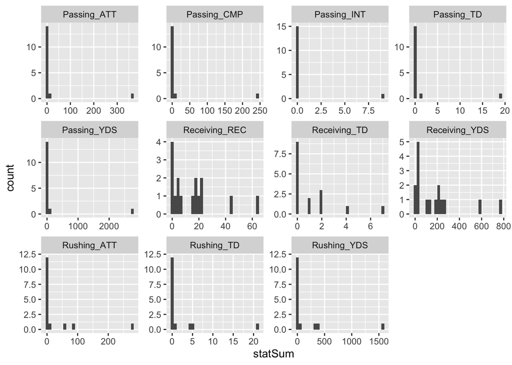

```r
ggplot(playerOffenseStat, aes(x=statSum)) +
  geom_histogram() + facet_wrap(~stat, scales = 'free')
```

From the histogram presented in the above, we can see that ISU football team is doing offensively better especially in receiving rec and receiving yds. These two facets (Receiving_REC and Receiving_YDS) tells that the are a few numbers of players has pretty far receiving yards and rec.

4. Did ISU have better offense against Oregon or Oklahoma? Answer this question by creating a scatterplot with the x- and y-axes being the receiving yards of the ISU players against each of these two opponents. A large number of receiving yards indicates good offense.

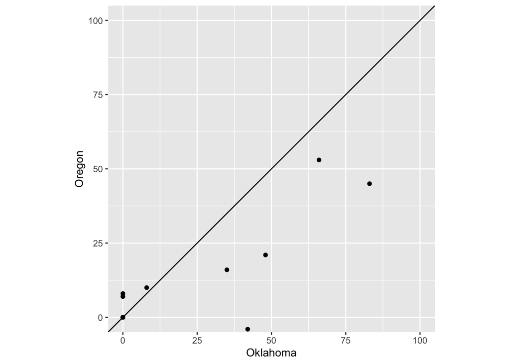

```r
oregonOklahoma <- offClean %>%
                  filter(Opponent_Opponent == 'Oklahoma' | Opponent_Opponent == 'Oregon') %>%
                  filter(stat == 'Receiving_YDS') %>% pivot_wider(names_from = Opponent_Opponent, values_from = Value)

ggplot(oregonOklahoma, aes(Oklahoma, Oregon)) + geom_point() + coord_fixed(xlim = c(0,100), ylim = c(0,100)) + geom_abline(intercept = 0, slope = 1)
```

The graph above separates the receiving yards of the ISU players data against Oregon and Oklahoma. The data below the line shows the performance of ISU players against Oklahoma, and the data above the the performance against Oregon. Since there are more data below the line, therefore, we can say that ISU players perform better against Oklahoma in terms of receiving yards.

5. Separate the `Hometown` column into two columns, namely, the city and the state where the player comes from. Print the first few rows of these two columns. (Hint: look at the `sep=` argument of `separate`)

```r
bioClean <- bioClean %>%
            separate(Hometown, c('city', 'state'), sep = ",", convert = TRUE)

cityStateBio <- bioClean %>% select(city, state)
head(cityStateBio)
```

```
##             city  state
## 1   Cedar Rapids   Iowa
## 2           Nixa    Mo.
## 3        Seffner   Fla.
## 4 Ft. Lauderdale   Fla.
## 5     Naperville   Ill.
## 6  Grand Prairie  Texas
```

6. How many players are there from each state?

```r
playersStateCount <- bioClean %>%
                      group_by(state) %>%
                      summarize(playersCount = n())

print(playersStateCount)
```

```
## # A tibble: 21 × 2
##    state        playersCount
##    <chr>               <int>
##  1 " Ariz."                4
##  2 " Ark."                 1
##  3 " Australia"            1
##  4 " Calif."               2
##  5 " Fla."                14
##  6 " Ga."                  3
##  7 " Ill."                 6
##  8 " Iowa"                42
##  9 " Kan."                 4
## 10 " Mich"                 1
## # … with 11 more rows
```

7. How does the performance of quarterback Brock Purdy relate to the performance of the ISU team? Comment on both the defense and offense.

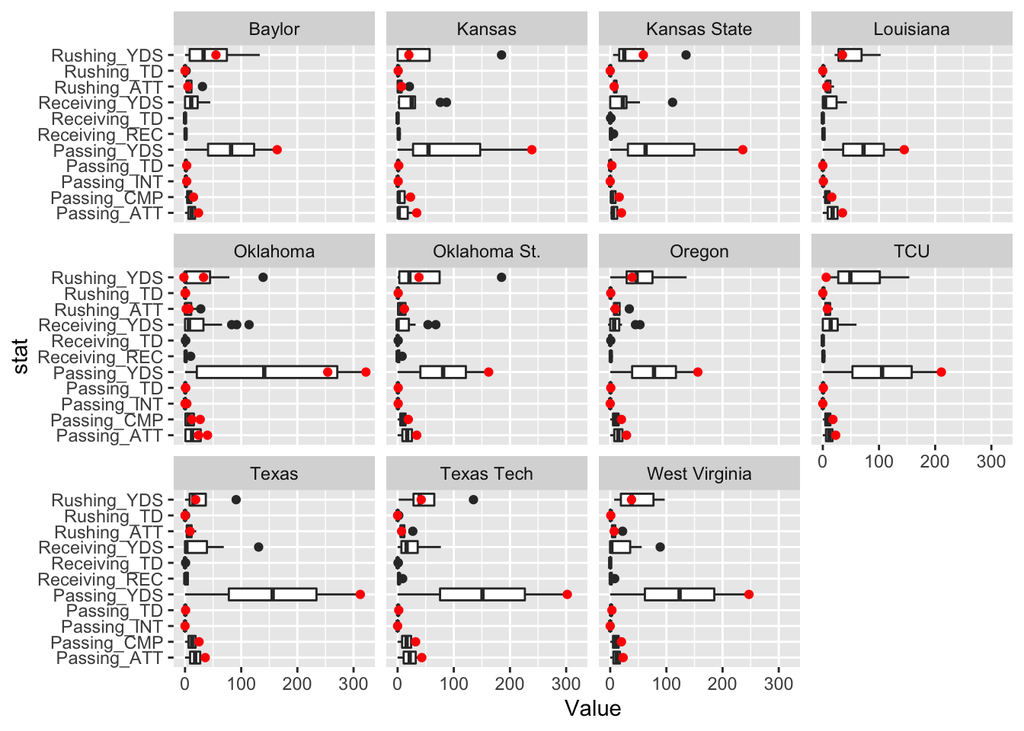

```r
offClean %>%
  mutate(PurdyStat = ifelse(Name == 'Purdy, Brock', Value, NA)) %>%
  ggplot() +
  geom_boxplot(aes(x = stat, y = Value)) +
  geom_point(aes(x = stat, y = PurdyStat), color = 'Red') +
  coord_flip() + facet_wrap(~Opponent_Opponent)
```

On the offensive point of view, Brock Purdy has done better than the average ISU team. Looking at the graph above, Brock Purdy has done an excellent job in passing yards for all the opponent he against with.

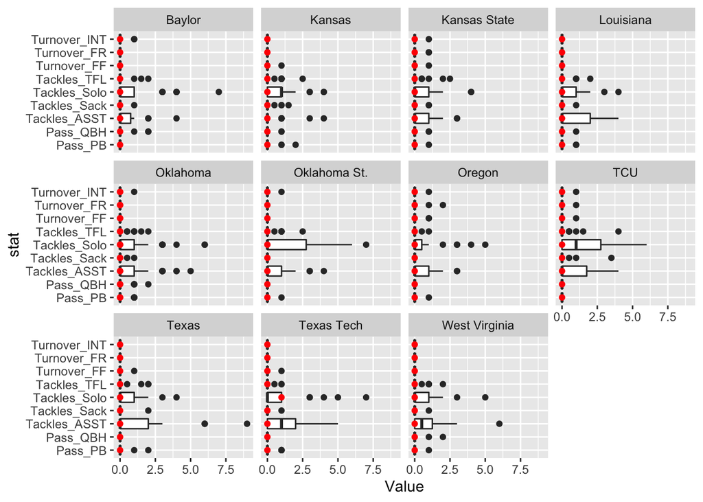

```r
# Transform defClean to a tidy data set
defClean <- defClean %>% pivot_longer(Tackles_Solo:Pass_PB, names_to = "stat", values_to = "Value")

defClean %>%
  mutate(PurdyStat = ifelse(Name == 'Purdy, Brock', Value, NA)) %>%
  ggplot() +
  geom_boxplot(aes(x = stat, y = Value)) +
  geom_point(aes(x = stat, y = PurdyStat), color = 'Red') +
  coord_flip() + facet_wrap(~Opponent_Opponent)
```

On the other hand, Brock Purdy is defensively poor compared to the other team. However, Brock Purdy has done slightly better in solo tackle against Texas Tech compared when he is playing against a different team.